# Notes on PaCMAP

November 14 2021

PaCMAP (Pairwise Controlled Manifold Approximation: [github](https://github.com/YingfanWang/PaCMAP), [arXiv](https://arxiv.org/abs/2012.04456), [JMLR](https://www.jmlr.org/papers/v22/20-1061.html)) is a UMAP/LargeVis-like method with a focus on maintaining global as well as local structure. In my opinion, its main innovation is advocating for the inclusion of “mid-near” pairs in the optimization. These are formed from finding points which aren’t the nearest neighbors but are closer on average than a random point from the dataset. The cost function in PaCMAP is also fairly simple, while maintaining some properties that the authors identify as important to avoid distorting local manifold structure while maintaining the good clustering behavior of UMAP.

## The Usual Preliminaries

The output coordinates of points $i$ is the vector $\mathbf{y_i}$. The distance between two output points $i$ and $j$ is the Euclidean distance given as $d_{ij}$. But we usually work with the squared distances:

$$d_{ij}^2 = \| \mathbf{y_i} - \mathbf{y_j} \|_2^2$$

Output similarities/weights are like those used in t-SNE, using a Cauchy-like function:

$$w_{ij} = \frac{1}{1 + d_{ij}^2}$$

Some derivatives:

$$\begin{aligned}
&\frac{\partial{d_{ij}}}{\partial{\mathbf{y_i}}} = \frac{1}{d_{ij}} \left( \mathbf{y_i} - \mathbf{y_j} \right)
\\
&\frac{\partial{w_{ij}}}{\partial{d_{ij}}} = -2 d_{ij} w_{ij}^2
\\
&\frac{\partial{w_{ij}}}{\partial{\mathbf{y_i}}} = -2 w_{ij}^2 \left( \mathbf{y_i} - \mathbf{y_j} \right)
\end{aligned}$$

and the gradient of the cost function is:

$$\frac{\partial{C}}{\partial{\mathbf{y_i}}} = -2 \frac{\partial{C}}{\partial{w_{ij}}} w_{ij}^2 \left(\mathbf{y_i} - \mathbf{y_j}\right)$$

As the cost function for this kind of dimensionality reduction method is usually given in terms of $w_{ij}$, we can concentrate on the form of $\partial{C}/\partial{w_{ij}}$ and plug it into the full gradient above if we want to write an actual implementation.

## Cost Function

In the PaCMAP paper, the cost function is defined in terms of $\tilde{d_{ij}}$, which is defined as:

$$\tilde{d_{ij}} = 1 + d_{ij}^2$$

I will be working with $w_{ij}$ rather than $\tilde{d_{ij}}$ where possible.

Near neighbor and mid-near attractive interactions are of the form:

$$C^{+}_{PaCMAP} = \frac{a\tilde{d_{ij}}}{b + \tilde{d_{ij}}} = \frac{a}{1 + bw_{ij}}$$

where $a$ is a positive scalar weight that changes over the course of the optimization to put different emphasis on local vs global pairs, and $b$ is a fixed positive value.

For non-neighbors (also referred to as “further” or “far” pairs), the repulsive interactions are:

$$C^{-}_{PaCMAP} = \frac{1}{1 + \tilde{d_{ij}}} = \frac{w_{ij}}{1 + w_{ij}}$$

In the paper, the repulsive interaction does have a weight associated it (i.e. the numerator can be > 1) but in practice the optimization procedure always fixes the numerator as 1, so for simplicity’s sake I have omitted it.

PaCMAP never gives a “full” cost function that we might expect: i.e. one that is defined over all possible pairs of points.

## Gradient

The derivative of the attractive interaction is:

$$\frac{\partial C_{PaCMAP}^+}{\partial{w_{ij}}} =
-\frac{ab}{\left(1 + bw_{ij}\right)^2}$$

and therefore the gradient is:

$$\frac{\partial C_{PaCMAP}^+}{\partial{\mathbf{y_i}}} =
2\frac{abw_{ij}^2}{\left(1 + bw_{ij}\right)^2} \left(\mathbf{y_i} - \mathbf{y_j}\right)$$

The derivative of the repulsive interaction is:

$$\frac{\partial C_{PaCMAP}^-}{\partial{w_{ij}}} =
\frac{1}{\left(1 + w_{ij}\right)^2}$$

hence the gradient is:

$$\frac{\partial C_{PaCMAP}^-}{\partial{\mathbf{y_i}}} =
-2\frac{w_{ij}^2}{\left(1 + w_{ij}\right)^2} \left(\mathbf{y_i} - \mathbf{y_j}\right)$$

(if you wanted to include an $a$ and $b$ in the repulsive contribution, the form of the gradient would look identical to the attractive interaction, but with a difference in sign).

### Comparison with UMAP

The equivalent gradients for UMAP are:

$$\begin{aligned}
& \frac{\partial C_{UMAP}^+}{\partial{\mathbf{y_i}}} = 2 w_{ij} \left(\mathbf{y_i} - \mathbf{y_j}\right) \\
& \frac{\partial C_{UMAP}^-}{\partial{\mathbf{y_i}}} =
-2\frac{w_{ij}^2}{1 - w_{ij}} \left(\mathbf{y_i} - \mathbf{y_j}\right)
\end{aligned}$$

I have made a simplifying assumption in the case of UMAP that the sampling of positive edges is uniform and the output weight function parameters are set so they match that of PaCMAP.

### Paper/Code form

Here is the gradient in terms of the expression in the paper and how it looks in the PaCMAP code.

This requires the following derivatives:

$$\begin{aligned}
&\frac{\partial{d_{ij}}}{\partial{\mathbf{y_i}}} = \frac{1}{d_{ij}} \left( \mathbf{y_i} - \mathbf{y_j} \right)
\\
&\frac{\partial{\tilde{d_{ij}}}}{\partial{d_{ij}}} = 2 d_{ij}
\\
&\frac{\partial{\tilde{d_{ij}}}}{\partial{\mathbf{y_i}}} = 2 \left( \mathbf{y_i} - \mathbf{y_j} \right)
\\
&\frac{\partial{C}}{\partial{\mathbf{y_i}}} = 2 \frac{\partial{C}}{\partial{\tilde{d_{ij}}}} \left(\mathbf{y_i} - \mathbf{y_j}\right)
\end{aligned}$$

The attractive derivative is:

$$\frac{\partial C_{PaCMAP}^+}{\partial{\tilde{d_{ij}}}} =
\frac{ab}{\left(b + \tilde{d_{ij}}\right)^2}$$

leading to the gradient:

$$\frac{\partial C_{PaCMAP}^+}{\partial{\mathbf{y_i}}} =
2\frac{ab}{\left(b + \tilde{d_{ij}}\right)^2} \left(\mathbf{y_i} - \mathbf{y_j}\right)$$

The repulsive derivative is:

$$\frac{\partial C_{PaCMAP}^-}{\partial{\tilde{d_{ij}}}} =
-\frac{1}{\left(1 + \tilde{d_{ij}}\right)^2}$$

giving:

$$\frac{\partial C_{PaCMAP}^-}{\partial{\mathbf{y_i}}} =
-2\frac{1}{\left(1 + \tilde{d_{ij}}\right)^2} \left(\mathbf{y_i} - \mathbf{y_j}\right)$$

### Some R functions

To convince myself that have correctly expressed these gradients are equivalent, here are two R functions that calculate the “force constant” part of the gradients (i.e. everything that isn’t the $\mathbf{y_i} - \mathbf{y_j}$ part):

```r
pacmap_kw <- function(dij, a = 1, b = 1) {
  dij2 <- dij * dij
  wij <- 1 / (1 + dij2)
  bw1 <- 1 + b * wij
  w1 <- 1 + wij
  list(
    attr = 2 * (a * b * wij * wij) / (bw1 * bw1),
    rep = -2 * wij * wij / (w1 * w1)
  )
}

pacmap_kd <- function(dij, a = 1, b = 1) {
  dij2 <- dij * dij
  dsquig <- 1 + dij2
  bd <- b + dsquig
  d1 <- 1 + dsquig
  list(
    attr = 2 * (a * b)  / (bd * bd),
    rep = -2 / (d1 * d1)
  )
}
```

## Weight Schedule

For neighbors, $b = 10$. For mid-near pairs, $b = 10000$. The $a$ weights (referred to as $w_{NB}$, $w_{MN}$ and $w_{FP}$ for “near pairs”, “mid-near pairs” and “further pairs” respectively in the paper) have different values at different points in the optimization schedule:

| Iteration | near | mid | further |
| --- | --- | --- | --- |
| 0 -> 100 | 2 | 1000 -> 3 | 1 |
| 101 -> 200 | 3 | 3 | 1 |
| 201 -> 450 | 1 | 0 | 1 |

I have kept the `further` weight column for consistency with the paper even though as you can see, far pair weights are always 1. For the mid-near pairs during the first 100 iterations, `1000 -> 3` means the weight is linearly decayed from 1000 to 3.

Neither the $a$ or $b$ parameters of the cost function can be modified by the user in the PaCMAP implementation. The number of iterations can be changed, but the first 200 iterations always use the same weights and schedule, so if you set `num_iters = 900`, this means the third stage of the optimization schedule will last for 700 iterations, rather than doubling the duration of all three stages proportionally.

## Force Constant Plots

To help compare with UMAP, I have plotted the attractive and repulsive “force constants”, $k_{attr}$ and $k_{rep}$, over the range of $w_{ij}$. The force constant is the bit of the gradient that isn’t the $\left(\mathbf{y_i} - \mathbf{y_j}\right)$ part, i.e. if you consider the layout to be about finding an equilibrium of points attached to springs, this is the stiffness of the spring between two points. Alternatively, consider this a gradient plot, given a fixed displacement of $\left(\mathbf{y_i} - \mathbf{y_j}\right) = 1$.

First, the attractive interactions of near neighbors:

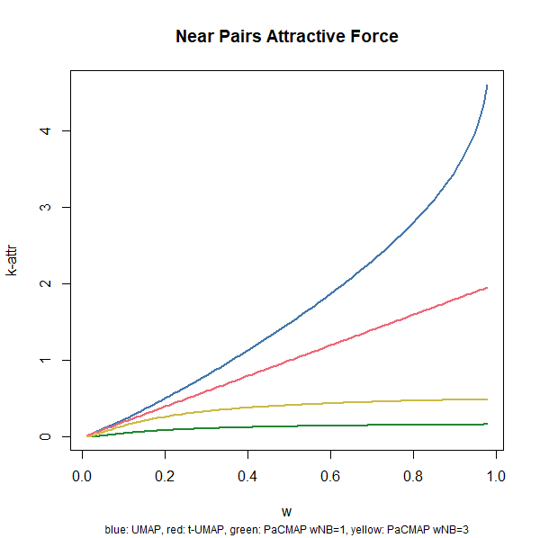

Attractive Forces

The blue line is UMAP with default settings. The red line is UMAP with the output function chosen to give the same $w_{ij}$ values as PaCMAP. This version of UMAP I will refer to as t-UMAP as it shares the same output weights as t-SNE as well as PaCMAP. The green line is PaCMAP with $a = w_{NB} = 1$, which occurs during the final part of the optimization, and the yellow is with $a = w_{NB} = 3$, which occurs during the middle part of the optimization. The UMAP forces are not only much higher, at least for the default settings, the attractive forces rapidly accelerate in magnitude for high $w$ (i.e. neighboring points in the embedding which are supposed to be close). For t-UMAP, the relationship between $w_{ij}$ and $k_{attr}$ is linear. For PaCMAP, there is a much more gentle increase in force as $w_{ij}$ increases, and the rate of change decreases rather than increases. For PaCMAP, a $w_{ij} >= 0.62$ feels at least 90% of the maximum attractive force whereas for UMAP, $w_{ij} >= 0.96$. To be pedantic, if we take into account UMAP’s gradient clipping, it’s actually $w_{ij} >= 0.92$, but the overall message stays the same.

We’ll come back to the mid-pairs after we have looked at the repulsive forces:

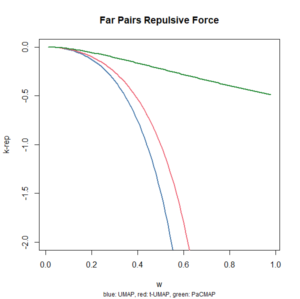

Repulsive Forces

The colors are the same as in the previous plot: blue for UMAP, red for t-UMAP and green for PaCMAP (there is only ever one weighting for the repulsive force). It’s hard to put the full range of forces for these methods in one plot, so I have zoomed in on the top portion of the plot. There is a very similar pattern as with the attractive forces: UMAP repulsions steeply increase as non-similar items get close together in the embedding. Nothing very interesting happens in the rest of the UMAP curves that aren’t shown here. Note that the repulsive gradient in UMAP requires a small positive value to prevent division by zero at very high $w_{ij}$, so repulsions can get very large and negative. The UMAP implementation clips the gradient so it doesn’t exceed `4`: this is the total gradient, not just the force constant, but that also puts an upper bound on the effective force constant as `4`. PaCMAP on the other hand has no singularities in its repulsion, (the maximum repulsion is `0.5`) and so no need need for gradient clipping. It also doesn’t show an acceleration in repulsion at high $w_{ij}$.

Finally, let’s look at the mid pair attractions, a PaCMAP-only feature:

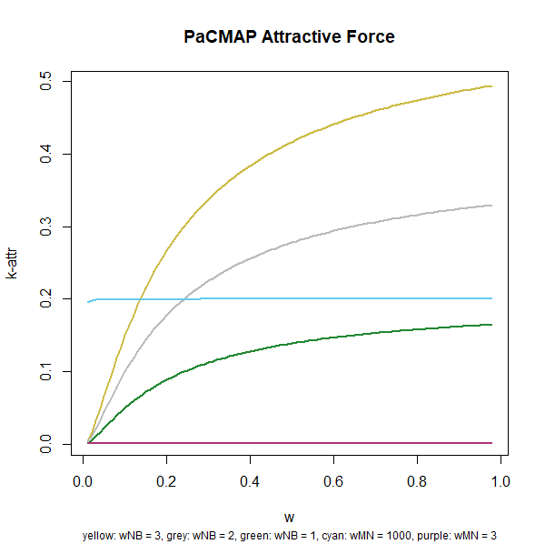

Mid Pair Attractive Forces

Overall, this seems to point to why UMAP can “tear” manifolds or promote clustering vs PaCMAP: forces (attractive or repulsive) which are much higher at high $w_{ij}$. Based on my experiments with the weighting parameters of the UMAP output weight function, I don’t think it’s possible to generate curves which look like that of PaCMAP (the t-UMAP curve is the best you can do).

## No Gradient Clipping

I discussed this in the section above, but it’s worth calling out as another point of difference with UMAP: the PaCMAP gradients don’t require clipping.

## Uniform Near Pair Weights

Note that for a given type of pair (e.g. near pairs), they all get the same weight. This is different to UMAP and LargeVis (and t-SNE), where there is an input weight calibration stage that puts a higher weight on pairs which have a higher similarity. In UMAP and LargeVis this manifests as certain edges being sampled more regularly during optimization. This is not the case for PaCMAP, which effectively assigns all pairs the same weight and samples every pair during each epoch

Alternatively, you could lump the near and mid-near pairs together as the “positive” edges, and consider PaCMAP as applying only 1 or 2 different possible weight values to the positive edges during any given epoch.

## Input Preprocessing

By default, if the input dimensionality $d > 100$ then the data is centered (but not scaled) and PCA is applied via the scikit-learn [TruncatedSVD](https://scikit-learn.org/stable/modules/generated/sklearn.decomposition.TruncatedSVD.html) to reduce the input dimensionality to 100. If PCA is not asked for (or the data is already low-dimensional), the data is range-scaled and then centered.

The Truncated SVD used in scikit-learn seems to use the same method by [Halko and co-workers](https://arxiv.org/abs/0909.4061) as used in irlba’s `svdr` function and cited by the [rsvd package](https://cran.r-project.org/package=rsvd) (see also the [github](https://github.com/erichson/rSVD) and [JSS publication](https://arxiv.org/abs/1608.02148)), but the scikit-learn version is noticeably faster than either (even after installing OpenBLAS for faster linear algebra routines on Linux). Results for the later dimensions are not the same between TruncatedSVD in Python and irlba, rsvd or even the unrelated bigstatsr package so there may be an accuracy/speed trade off to be investigated on the R side.

*16 November 2021* I have confirmed something along these lines for the `macosko2015` dataset (of dimensions `44808 x 3000`). For centered but unscaled data, extracting 100 components explains around 37% of the variance, so differences in results aren’t due to numerical issues that arise when all the variance in a dataset has been extracted and the last few columns are just creative ways of expressing a vector that should be full of zeros. The `TruncatedSVD` (in version 1.0 of scikit-learn) with default parameters produces columns which are substantially less orthogonal than those produced by the R packages mentioned above. After normalizing the columns, the dot products of successive columns are fairly uniform across all 100 columns for all the R methods, in the region of $10^{-14}$ to $10^{-16}$. For `TruncatedSVD`, the columns start at a comparable level of orthogonality but quickly become less orthogonal. The dot product of the tenth and eleventh column is around $10^{-7}$ and for the last ten columns the dot products are in the region of $10^{-4}$ to $10^{-5}$. This suggests that for the purposes of approximate nearest neighbor search, initial dimensionality reduction via SVD may be able to use substantially looser tolerances than the defaults used in many R packages.

## Nearest Neighbors

The number of nearest neighbors is scaled according to dataset size. For $N < 10000$, the number of neighbors = 10. For $N > 10000$ the following formula is used:

$$n_{nbrs} = \left \lfloor 10 + 15 \left(\log_{10}n - 4\right) \right \rceil$$

where $\left \lfloor \cdot \right \rceil$ indicates my cumbersome attempt to communicate “round to the nearest integer”.

Perhaps some examples would help:

| $N$ | $n_{nbrs}$ |
| --- | --- |
| 10 000 | 10 |
| 20 000 | 15 |
| 50 000 | 20 |
| 60 000 | 22 |
| 70 000 | 23 |
| 100 000 | 25 |
| 1 000 000 | 40 |

If you didn’t want to think about it, it seems like setting `n_neighbors = 20` would be fine.

### The Approximate Nearest Neighbor Calculation

[Annoy](https://github.com/spotify/annoy) is used for nearest neighbor calculations. `n_trees = 20`. Instead of finding the `n_neighbors` nearest neighbors however, actually `n_neighbors + 50` are searched for. This is to allow finding the neighbors with the smallest scaled distances (see below).

PaCMAP supports all the distance metrics that Annoy does (i.e. Cosine, Manhattan and Hamming in addition to Euclidean). There is one odd wrinkle to this (see the mid-near section below).

### Scaled Distances

The closest `n_neighbors` of each point are not actually used. Instead the `n_neighbors` closest points in terms of a “generalized” squared distance, originally proposed by [Zelnik-Manor and Perona](https://papers.nips.cc/paper/2004/hash/40173ea48d9567f1f393b20c855bb40b-Abstract.html), is used:

$$d_{ij}^{2,select} = \frac{r_{ij}^2}{\sigma_i \sigma_j}$$

where $r_{ij}^2$ represents the distance in the input space. The local scaling factor $\sigma_i$ is the mean average (unscaled) distance of the 4th-6th nearest neighbors of $i$. This choice for $\sigma_i$ is the same as that used in the Trimap method ([github](https://github.com/eamid/trimap), [arXiv](https://arxiv.org/abs/1910.00204)).

The closest scaled distance neighbors are searched from within the `n_neighbors + 50` with the smallest unscaled nearest neighbors. Scaled distances are not used in any other part of the method.

*11th January 2022*: note that the $i$th observation will always find itself as its own nearest neighbor (or tied in the case with duplicates). PaCMAP accounts for this by actually looking at `n_neighbors + 51` and ignoring the actual closest neighbor.

Roughly then we can expect to be looking for `60-75` nearest neighbors for datasets up to $N = 100 000$.

## Mid Near Neighbors

The default number of mid-near neighbors is half that of the near neighbors (rounded to the nearest integer). Each mid-near neighbor is chosen by picking six items at random and keeping the one with the second-smallest distance. Note that scaled distances are *not* used here.

Oddly, Euclidean distance is always used for measuring the distances at this point no matter what distance metric was chosen for the near neighbors.

If we consider the near and mid-near neighbors together as making up the “positive” edges that feel an attractive interaction during optimization, we are using around `15-38` neighbors up to $N = 100 000$.

## Far Pairs

As in UMAP, these are picked with at (uniform) random.

## Neighbors are Sampled Once and Re-used

In UMAP and LargeVis, the “negative” sampling (same as “far pairs” here) is repeated during each epoch, so a given point $i$ always gets an entirely new set of far pairs. PaCMAP samples both the mid-near and far pairs once before the optimization begins and re-uses them at each epoch. This saves on repeated random number generation, at the cost of increased memory usage for storing the indices of the pairs. With default settings we can expect an extra storage cost of $2.5 * N * n_{nbrs}$, which technically would make PaCMAP’s memory costs scale as $O(N \log N)$.

## Output Initialization

The default initialization uses PCA. The resulting coordinates are all shrunk by a factor of `0.01`. Alternatively a random initialization is available using the standard t-SNE initialization of random normal variables with a standard deviation of `1e-4`. If a user-supplied matrix is provided, the coordinates are centered and then shrunk by a factor of `1e-4`.

## Optimization

Unlike UMAP and LargeVis, PaCMAP updates the embedding using a full batch gradient, i.e. coordinates are updated all at once at the end of each epoch. The gradient is still stochastic however.

Optimization is carried out using [Adam](https://arxiv.org/abs/1412.6980), popular in deep learning (or at least popular among people who write papers about deep learning). The momentum parameters $\beta_1$ and $\beta_2$ are kept at their default values ($0.9$ and $0.999$ respectively). The learning rate $\alpha = 1$ and $\epsilon = 10^{-7}$. The latter was intended only to prevent division by zero (although different values [may also affect performance](https://papers.nips.cc/paper/2018/hash/90365351ccc7437a1309dc64e4db32a3-Abstract.html)).

## PaCMAP reports its Stochastic Cost

As can be seen in the consideration of the gradients, the per-point PaCMAP loss can be easily calculated using values needed for the gradient. PaCMAP stores the loss at the end of the gradient vector and can report it at different stages during the optimization. Because the negative pairs are constant for the entire optimization, we might expect there to be less variance than if a UMAP-style approach to negative sampling was used. On the other hand, presumably this cost function has a higher bias. And the variance issue may still bite you if you try to compare different costs between different runs with different random number seeds.

## Pairwise Distance Comparison

To get a feel for the effect of the different neighbor calculations, here are some histograms of pairwise distances for different sets of exact nearest neighbors across a variety of datasets. Neither UMAP nor PaCMAP use exact nearest neighbors, but it’s one less variable to worry about. The different sets of neighbors are labelled as:

- `15`: The 15 nearest neighbors. Actually it’s only the 14 nearest neighbors because I omit the first nearest neighbor of each item which is always itself. These are the exact nearest neighbors, not the result of an approximate nearest neighbor calculation. This is the UMAP default value.
- `15s`: The 15 nearest neighbors using the scaled distances. These are selected from the exact nearest 65 neighbors, as would be done in PaCMAP (i.e. `n_neighbors + 50`).
- `150`: The 150 exact nearest neighbors. This is an order of magnitude higher than the UMAP default, and would be the upper limit to the usual nearest neighbor calculation in t-SNE, where often 3 * perplexity is used, and perplexity is rarely set higher than 50.
- `mid near`: The mid near pairs, calculated as described above. Default in PaCMAP is to calculate as many mid near pairs as `0.5 * n_neighbors`, but I have calculated it using 15 mid near pairs for consistency (there is no effect on the shape of the distribution of distances).
- `random`: 15 random neighbors.

For each of these set of neighbors, a histogram was generated of the distances. I used the Euclidean distance in all cases. Overlaying all these histograms on top of each other is way too confusing, so I have generated them using the same break points on separate plots. Each column in the table below is one dataset, so by looking down a column you can see how the pair-wise distance distribution changes. I would expect the distances to increase as you look down the column.

The first three are low-dimensional (2 or 3 dimensions) quite highly structured datasets. The `mammoth` dataset has 10,000 points and 3 features (X, Y, Z coordinates: it’s a 3D model of a mammoth). `sch10k` is the s-curve with a hole also with 10,000 points and X, Y, Z coordinates. This is an S-shaped curve which has a circular hole right in the middle (in the middle of the ‘S’). The `curve2d` is a 2D polynomial (1,450 points).

mammoth

sch10k

curve2d

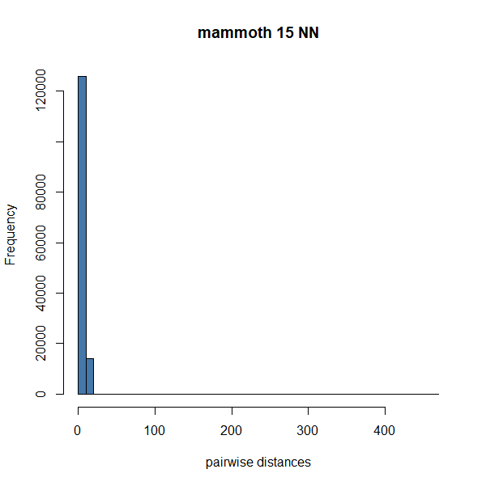

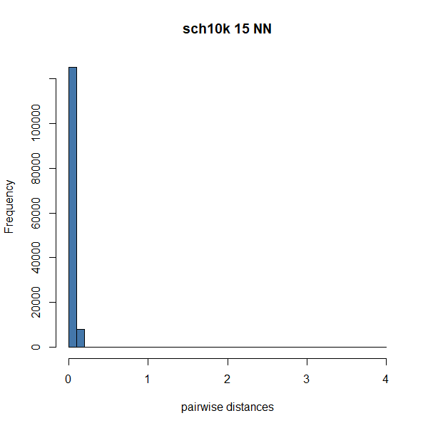

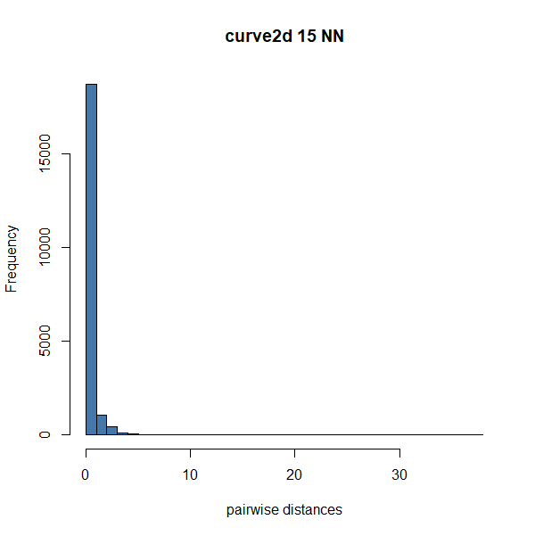

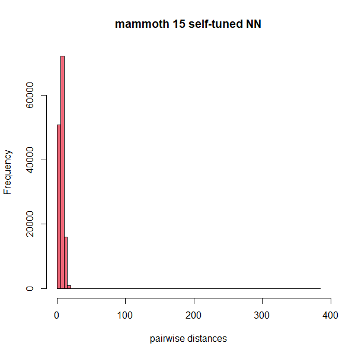

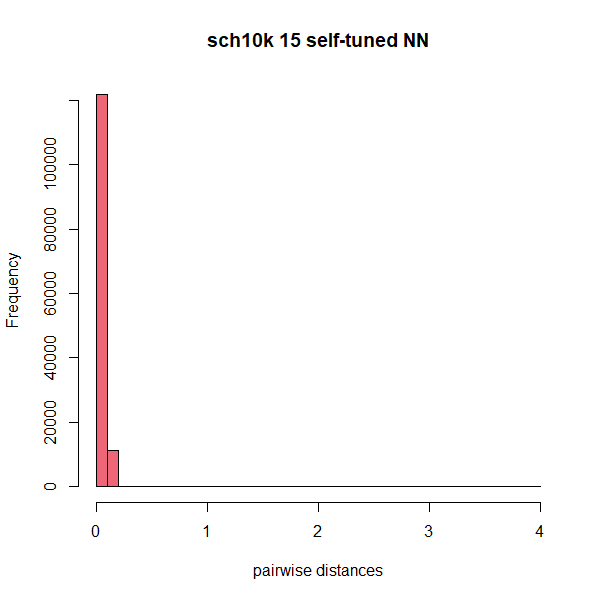

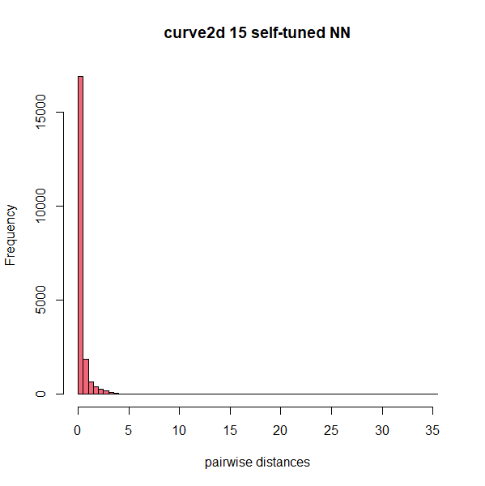

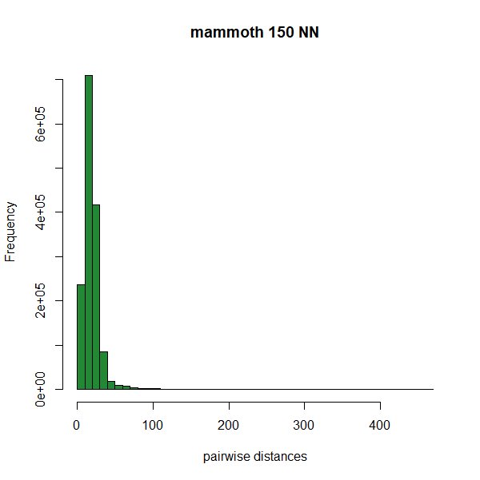

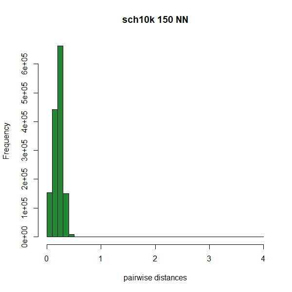

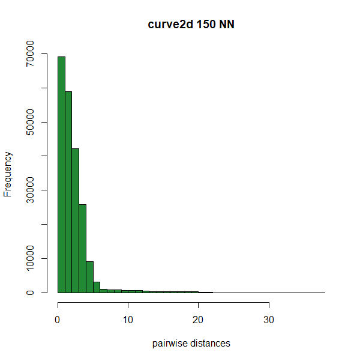

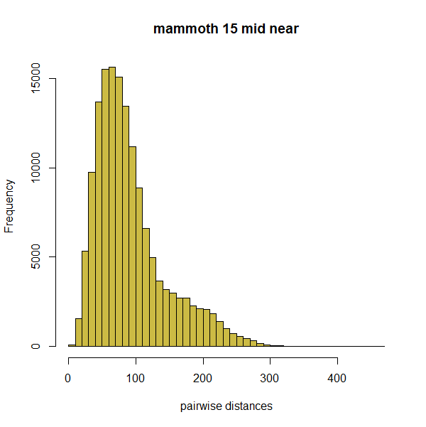

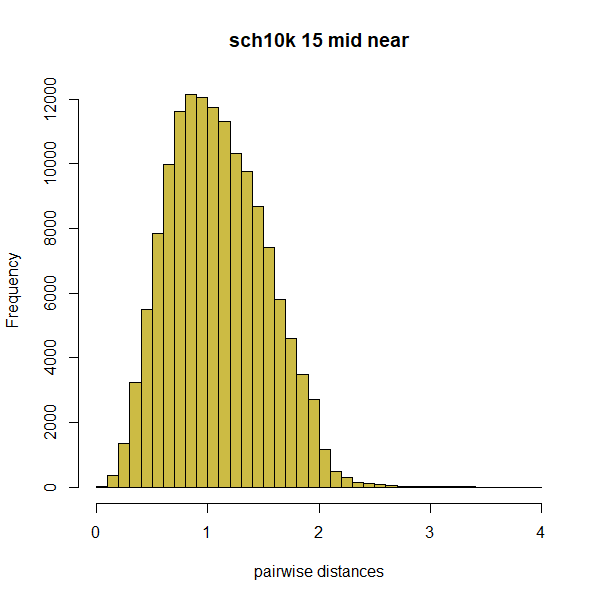

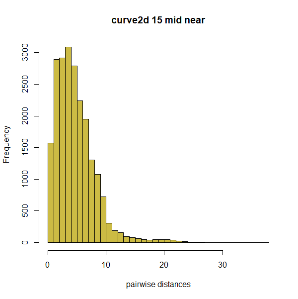

[3 more figures not shown]

The next three datasets are all image datasets. They are fairly small in terms of number of objects, but are quite high dimensional (features are pixels). `coil20` is a set of 20 objects in 72 poses each (so 1440 items altogether) and 16384 features. `frey` is a set of 1965 video stills of Brendan Frey’s face with 560 features. `oli` is the Olivetti faces (40 faces, 10 images each) with 4096 features.

coil20

frey

oli

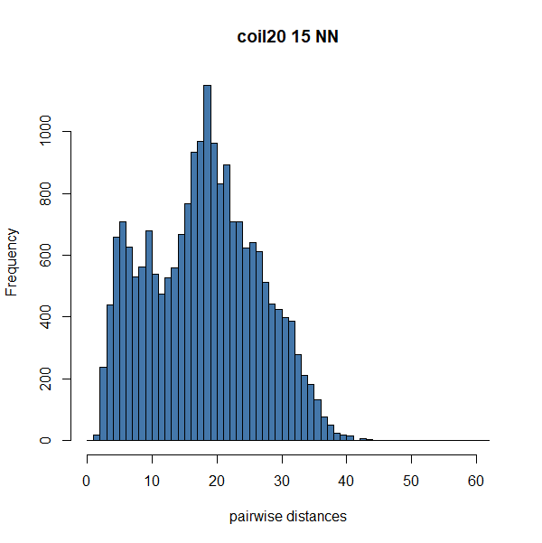

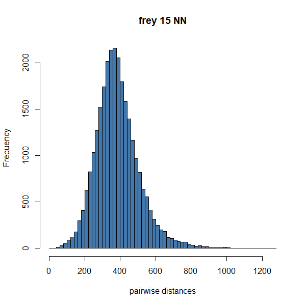

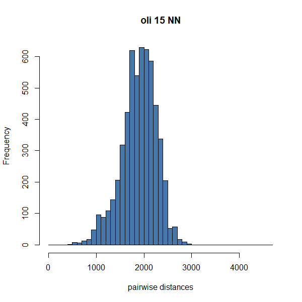

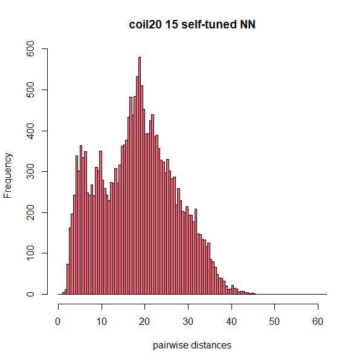

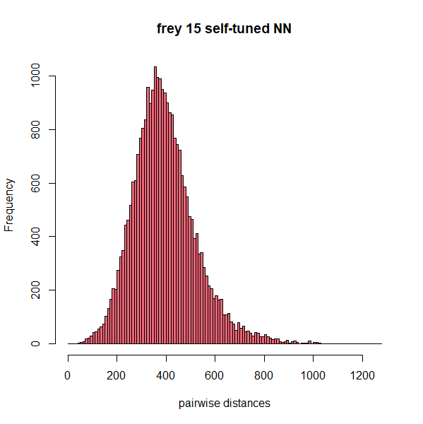

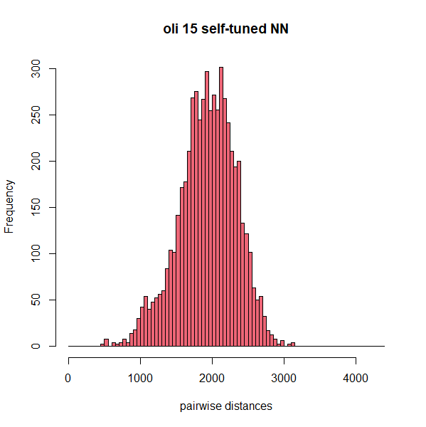

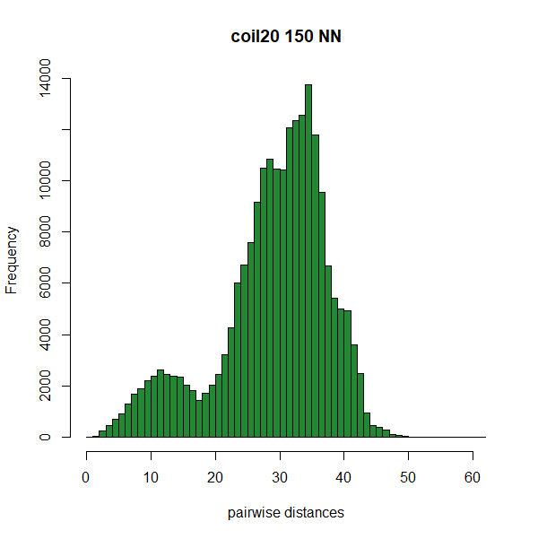

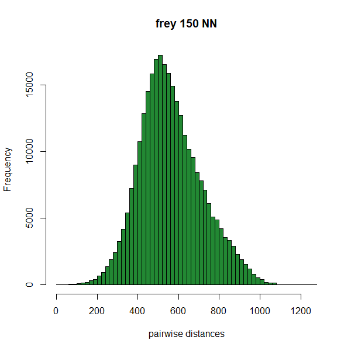

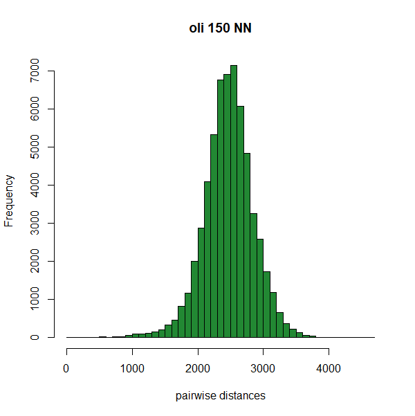

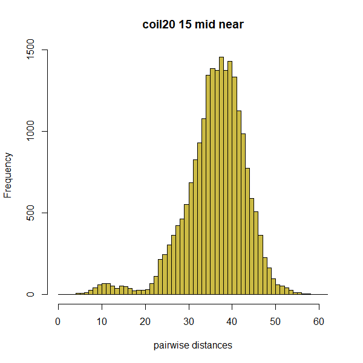

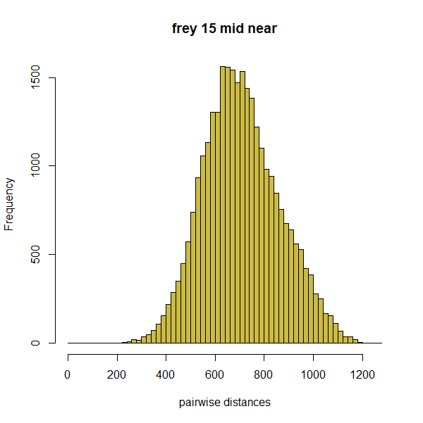

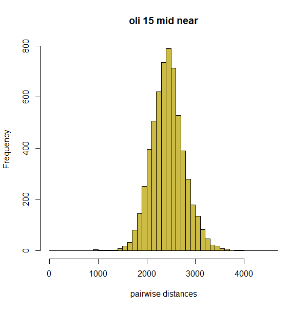

[3 more figures not shown]

The next three datasets are of identical dimensions: 70000 images, with 784 features (pixels). `mnist` are handwritten digits, `fashion` are images of items of clothing, `kuzushiji` is handwritten Japanese characters.

mnist

fashion